# RFM

Cargar librerias

```python
import numpy as np
import pandas as pd
import matplotlib.pyplot as plt
import seaborn as sb

import time, warnings
import datetime as dt

from pandas.plotting import scatter_matrix
%matplotlib inline

warnings.filterwarnings("ignore")
```

Cargar DataSet

```python
retail_df = pd.read_csv("retail_data.csv", encoding="ISO-8859-1",dtype={'CustomerID': str,'InvoiceID': str})
retail_df.head()
```

|  | InvoiceNo | StockCode | Description | Quantity | InvoiceDate | UnitPrice | CustomerID | Country |
| --- | --- | --- | --- | --- | --- | --- | --- | --- |
| 0 | 581587 | 22631 | CIRCUS PARADE LUNCH BOX | 12 | 12/9/2011 12:50 | 1.95 | 12680 | France |
| 1 | 581587 | 22556 | PLASTERS IN TIN CIRCUS PARADE | 12 | 12/9/2011 12:50 | 1.65 | 12680 | France |
| 2 | 581587 | 22555 | PLASTERS IN TIN STRONGMAN | 12 | 12/9/2011 12:50 | 1.65 | 12680 | France |
| 3 | 581587 | 22728 | ALARM CLOCK BAKELIKE PINK | 4 | 12/9/2011 12:50 | 3.75 | 12680 | France |
| 4 | 581587 | 22727 | ALARM CLOCK BAKELIKE RED | 4 | 12/9/2011 12:50 | 3.75 | 12680 | France |

```python
retail_df.shape
```

```
(541909, 8)
```

# Agrupar por país

```python
print(retail_df.groupby('Country').size())
```

```
Country
Australia                 1259
Austria                    401
Bahrain                     19
Belgium                   2069
Brazil                      32
Canada                     151
Channel Islands            758
Cyprus                     622
Czech Republic              30
Denmark                    389
EIRE                      8196
European Community          61
Finland                    695
France                    8557
Germany                   9495
Greece                     146
Hong Kong                  288
Iceland                    182
Israel                     297
Italy                      803
Japan                      358
Lebanon                     45
Lithuania                   35
Malta                      127
Netherlands               2371
Norway                    1086
Poland                     341
Portugal                  1519
RSA                         58
Saudi Arabia                10
Singapore                  229
Spain                     2533
Sweden                     462
Switzerland               2002
USA                        291
United Arab Emirates        68
United Kingdom          495478
Unspecified                446
dtype: int64
```

Análisis y preparación de los datos

Tomar los datos de UK

```python
retail_uk = retail_df[retail_df['Country']=='United Kingdom']
#check the shape
retail_uk.shape
```

```
(495478, 8)
```

# remover las ordenes canceladas

```python
retail_uk = retail_uk[retail_uk['Quantity']>0]
retail_uk.shape
```

```
(486286, 8)
```

# remover filas donde el ID de cliente es NA

```python
retail_uk.dropna(subset=['CustomerID'],how='all',inplace=True)
retail_uk.shape
```

```
(354345, 8)
```

# restrinja los datos a un año completo porque es mejor usar una métrica por Meses o Años en RFM

```python
retail_uk = retail_uk[retail_uk['InvoiceDate']>= "2010-12-09"]
retail_uk.shape
```

```
(176137, 8)
```

# explorar los valores únicos de cada atributo

```python
print("Summary..")

print("Number of transactions: ", retail_uk['InvoiceNo'].nunique())
print("Number of products bought: ",retail_uk['StockCode'].nunique())
print("Number of customers:", retail_uk['CustomerID'].nunique() )
print("Percentage of customers NA: ", round(retail_uk['CustomerID'].isnull().sum() * 100 / len(retail_df),2),"%" )
```

```
Summary..
Number of transactions:  8789
Number of products bought:  3294
Number of customers: 2864
Percentage of customers NA:  0.0 %
```

```python
retail_uk.head()
```

|  | InvoiceNo | StockCode | Description | Quantity | InvoiceDate | UnitPrice | CustomerID | Country |
| --- | --- | --- | --- | --- | --- | --- | --- | --- |
| 171229 | 569148 | 23130 | MISTLETOE HEART WREATH GREEN | 4 | 9/30/2011 15:52 | 4.15 | 16613 | United Kingdom |
| 171230 | 569148 | 23129 | HEART SHAPED HOLLY WREATH | 4 | 9/30/2011 15:52 | 4.15 | 16613 | United Kingdom |
| 171231 | 569148 | 22086 | PAPER CHAIN KIT 50'S CHRISTMAS | 12 | 9/30/2011 15:52 | 2.95 | 16613 | United Kingdom |
| 171232 | 569148 | 23221 | REINDEER HEART DECORATION SILVER | 24 | 9/30/2011 15:52 | 0.83 | 16613 | United Kingdom |
| 171233 | 569148 | 23223 | CHRISTMAS TREE HANGING SILVER | 24 | 9/30/2011 15:52 | 0.83 | 16613 | United Kingdom |

# ANÁLISIS RFM

# Recency

Para calcular la variable Reciente, debemos elegir un punto en el tiempo a partir del cual evaluamos hace cuántos días fue la última compra del cliente.

```python
retail_uk['InvoiceDate'].max()
```

```
'9/9/2011 9:52'
```

Realmente la última fecha fue 2011-12-09 por lo que la usaremos como nuestra referencia.

```python
now = dt.date(2011,12,9)
print(now)
```

```
2011-12-09
```

# crear una nueva columna llamada fecha que contenga solo la fecha de la factura

```python
retail_uk['date'] = pd.DatetimeIndex(retail_uk['InvoiceDate']).date
```

```python
retail_uk.head()
```

|  | InvoiceNo | StockCode | Description | Quantity | InvoiceDate | UnitPrice | CustomerID | Country | date |
| --- | --- | --- | --- | --- | --- | --- | --- | --- | --- |
| 171229 | 569148 | 23130 | MISTLETOE HEART WREATH GREEN | 4 | 9/30/2011 15:52 | 4.15 | 16613 | United Kingdom | 2011-09-30 |
| 171230 | 569148 | 23129 | HEART SHAPED HOLLY WREATH | 4 | 9/30/2011 15:52 | 4.15 | 16613 | United Kingdom | 2011-09-30 |
| 171231 | 569148 | 22086 | PAPER CHAIN KIT 50'S CHRISTMAS | 12 | 9/30/2011 15:52 | 2.95 | 16613 | United Kingdom | 2011-09-30 |
| 171232 | 569148 | 23221 | REINDEER HEART DECORATION SILVER | 24 | 9/30/2011 15:52 | 0.83 | 16613 | United Kingdom | 2011-09-30 |
| 171233 | 569148 | 23223 | CHRISTMAS TREE HANGING SILVER | 24 | 9/30/2011 15:52 | 0.83 | 16613 | United Kingdom | 2011-09-30 |

```python
retail_uk.shape
```

```
(176137, 9)
```

# vereficamos que no tengamos datos perdidos

```python
retail_uk.info(verbose=True,null_counts=True)
```

```
<class 'pandas.core.frame.DataFrame'>
Int64Index: 176137 entries, 171229 to 436573
Data columns (total 9 columns):
 #   Column       Non-Null Count   Dtype
---  ------       --------------   -----
 0   InvoiceNo    176137 non-null  object
 1   StockCode    176137 non-null  object
 2   Description  176137 non-null  object
 3   Quantity     176137 non-null  int64
 4   InvoiceDate  176137 non-null  object
 5   UnitPrice    176137 non-null  float64
 6   CustomerID   176137 non-null  object
 7   Country      176137 non-null  object
 8   date         176137 non-null  object
dtypes: float64(1), int64(1), object(7)
memory usage: 13.4+ MB
```

# agrupamos por clientes y comprobamos última fecha de compra.

```python
recency_df = retail_uk.groupby(by='CustomerID', as_index=False)['date'].max()
recency_df.columns = ['CustomerID','LastPurshaceDate']
recency_df.head()
```

|  | CustomerID | LastPurshaceDate |
| --- | --- | --- |
| 0 | 12747 | 2011-08-22 |
| 1 | 12748 | 2011-09-30 |
| 2 | 12749 | 2011-08-01 |
| 3 | 12820 | 2011-09-26 |
| 4 | 12821 | 2011-05-09 |

# calculamos Recency

```python
recency_df['Recency'] = recency_df['LastPurshaceDate'].apply(lambda x: (now - x).days)
```

```python
recency_df.head()
```

|  | CustomerID | LastPurshaceDate | Recency |
| --- | --- | --- | --- |
| 0 | 12747 | 2011-08-22 | 109 |
| 1 | 12748 | 2011-09-30 | 70 |
| 2 | 12749 | 2011-08-01 | 130 |
| 3 | 12820 | 2011-09-26 | 74 |
| 4 | 12821 | 2011-05-09 | 214 |

# borramos LastPurchaseDate ya que no se necesita para más nada.

```python
recency_df.drop('LastPurshaceDate',axis=1,inplace=True)
```

```python
recency_df.head()
```

|  | CustomerID | Recency |
| --- | --- | --- |
| 0 | 12747 | 109 |
| 1 | 12748 | 70 |
| 2 | 12749 | 130 |
| 3 | 12820 | 74 |
| 4 | 12821 | 214 |

# Frequency

#Generamos una copia del df y borramos duplicados.

```python
retail_uk_copy = retail_uk
retail_uk_copy.drop_duplicates(subset=['InvoiceNo', 'CustomerID'], keep="first", inplace=True)
```

```python
#calculamos Frequency de compras
```

```python
frequency_df = retail_uk_copy.groupby(by=['CustomerID'], as_index=False)['InvoiceNo'].count()
frequency_df.columns = ['CustomerID','Frequency']
frequency_df.head()
```

|  | CustomerID | Frequency |
| --- | --- | --- |
| 0 | 12747 | 5 |
| 1 | 12748 | 96 |
| 2 | 12749 | 3 |
| 3 | 12820 | 1 |
| 4 | 12821 | 1 |

# Monetary

# creamos columna para total revenue

```python
retail_uk['TotalRevenue'] = retail_uk['Quantity'] * retail_uk['UnitPrice']
```

```python
monetary_df = retail_uk.groupby(by='CustomerID',as_index=False).agg({'TotalRevenue': 'sum'})
monetary_df.columns = ['CustomerID','Monetary']
monetary_df.head()
```

|  | CustomerID | Monetary |
| --- | --- | --- |
| 0 | 12747 | 191.85 |
| 1 | 12748 | 1048.83 |
| 2 | 12749 | 67.00 |
| 3 | 12820 | 15.00 |
| 4 | 12821 | 19.92 |

# Create RFM Tabla

# emergemos Recency dataframe con Frequency dataframe

```python
temp_df = recency_df.merge(frequency_df,on='CustomerID')
temp_df.head()
```

|  | CustomerID | Recency | Frequency |
| --- | --- | --- | --- |
| 0 | 12747 | 109 | 5 |
| 1 | 12748 | 70 | 96 |
| 2 | 12749 | 130 | 3 |
| 3 | 12820 | 74 | 1 |
| 4 | 12821 | 214 | 1 |

# emergemos con Monetary dataframe para obtener una tabla con las 3 columnas

```python
rfm_df = temp_df.merge(monetary_df,on='CustomerID')

rfm_df.set_index('CustomerID',inplace=True)

rfm_df.head(10)
```

| CustomerID | Recency | Frequency | Monetary |
| --- | --- | --- | --- |
| 12747 | 109 | 5 | 191.85 |
| 12748 | 70 | 96 | 1048.83 |
| 12749 | 130 | 3 | 67.00 |
| 12820 | 74 | 1 | 15.00 |
| 12821 | 214 | 1 | 19.92 |
| 12822 | 70 | 2 | 30.80 |
| 12823 | 74 | 3 | 1224.00 |
| 12826 | 71 | 2 | 37.30 |
| 12828 | 99 | 3 | 74.10 |
| 12830 | 91 | 5 | 1556.64 |

# RFM Tabla verificación

```python
retail_uk[retail_uk['CustomerID']=='12820']
```

|  | InvoiceNo | StockCode | Description | Quantity | InvoiceDate | UnitPrice | CustomerID | Country | date | TotalRevenue |
| --- | --- | --- | --- | --- | --- | --- | --- | --- | --- | --- |
| 181328 | 568236 | 23328 | SET 6 SCHOOL MILK BOTTLES IN CRATE | 4 | 9/26/2011 11:49 | 3.75 | 12820 | United Kingdom | 2011-09-26 | 15.0 |

```python
(now - dt.date(2011,9,26)).days == 74
```

```
True
```

```python
retail_uk[retail_uk['CustomerID']=='12748']
```

|  | InvoiceNo | StockCode | Description | Quantity | InvoiceDate | UnitPrice | CustomerID | Country | date | TotalRevenue |
| --- | --- | --- | --- | --- | --- | --- | --- | --- | --- | --- |
| 171875 | 569123 | 21882 | SKULLS TAPE | 2 | 9/30/2011 13:09 | 0.65 | 12748 | United Kingdom | 2011-09-30 | 1.30 |
| 172108 | 569100 | 90152A | SILVER/NAT SHELL NECKLACE W PENDANT | 1 | 9/30/2011 12:19 | 5.95 | 12748 | United Kingdom | 2011-09-30 | 5.95 |
| 176509 | 568703 | 22062 | CERAMIC BOWL WITH LOVE HEART DESIGN | 12 | 9/28/2011 15:21 | 0.83 | 12748 | United Kingdom | 2011-09-28 | 9.96 |
| 180083 | 568384 | M | Manual | 1 | 9/27/2011 9:46 | 0.00 | 12748 | United Kingdom | 2011-09-27 | 0.00 |
| 180169 | 568374 | 84660A | WHITE STITCHED WALL CLOCK | 20 | 9/26/2011 16:59 | 0.79 | 12748 | United Kingdom | 2011-09-26 | 15.80 |
| ... | ... | ... | ... | ... | ... | ... | ... | ... | ... | ... |
| 424002 | 546412 | 84993A | 75 GREEN PETIT FOUR CASES | 2 | 3/11/2011 16:50 | 0.42 | 12748 | United Kingdom | 2011-03-11 | 0.84 |
| 424580 | 546381 | 21181 | PLEASE ONE PERSON METAL SIGN | 1 | 3/11/2011 12:29 | 2.10 | 12748 | United Kingdom | 2011-03-11 | 2.10 |
| 424589 | 546380 | 21937 | STRAWBERRY PICNIC BAG | 1 | 3/11/2011 12:26 | 2.95 | 12748 | United Kingdom | 2011-03-11 | 2.95 |
| 424730 | 546366 | 48187 | DOORMAT NEW ENGLAND | 2 | 3/11/2011 11:37 | 7.95 | 12748 | United Kingdom | 2011-03-11 | 15.90 |
| 428408 | 545979 | 20713 | JUMBO BAG OWLS | 1 | 3/8/2011 12:30 | 1.95 | 12748 | United Kingdom | 2011-03-08 | 1.95 |

96 rows × 10 columns

# Segmentación Consumidores con RFM Model

La forma más sencilla de crear segmentos de clientes a partir del modelo RFM es utilizar cuartiles.

Asignamos una puntuación de 1 a 4 a Reciente, Frecuencia y Monetario.

# RFM Cuartiles

```python
quantiles = rfm_df.quantile(q=[0.25,0.5,0.75])
quantiles
```

|  | Recency | Frequency | Monetary |
| --- | --- | --- | --- |
| 0.25 | 85.0 | 1.0 | 16.350 |
| 0.50 | 119.0 | 2.0 | 35.400 |
| 0.75 | 183.0 | 3.0 | 92.025 |

Convierta el DataFrame en un diccionario.

El tipo key-value se puede personalizar con los parámetros (ver más abajo).

```python
quantiles.to_dict()
```

```
{'Recency': {0.25: 85.0, 0.5: 119.0, 0.75: 183.0},
 'Frequency': {0.25: 1.0, 0.5: 2.0, 0.75: 3.0},
 'Monetary': {0.25: 16.35, 0.5: 35.400000000000006, 0.75: 92.025}}
```

# Creación de Segmentos RFM

Crearemos dos clases de segmentación ya que la alta antigüedad es mala, mientras que la alta frecuencia y el valor monetario son buenos.

# Arguments (x = value, p = recency, monetary_value, frequency, d = quartiles dict)

```python
def RScore(x,p,d):
    if x <= d[p][0.25]:
        return 4
    elif x <= d[p][0.50]:
        return 3
    elif x <= d[p][0.75]:
        return 2
    else:
        return 1
```

```python
def FMScore(x,p,d):
    if x <= d[p][0.25]:
        return 1
    elif x <= d[p][0.50]:
        return 2
    elif x <= d[p][0.75]:
        return 3
    else:
        return 4
```

# crear segmentos rfm segmentation tabla.

```python
rfm_segmentation = rfm_df
rfm_segmentation['R_Quartile'] = rfm_segmentation['Recency'].apply(RScore, args=('Recency',quantiles,))
rfm_segmentation['F_Quartile'] = rfm_segmentation['Frequency'].apply(FMScore, args=('Frequency',quantiles,))
rfm_segmentation['M_Quartile'] = rfm_segmentation['Monetary'].apply(FMScore, args=('Monetary',quantiles,))
```

```python
rfm_segmentation.head()
```

| CustomerID | Recency | Frequency | Monetary | R_Quartile | F_Quartile | M_Quartile |
| --- | --- | --- | --- | --- | --- | --- |
| 12747 | 109 | 5 | 191.85 | 3 | 4 | 4 |
| 12748 | 70 | 96 | 1048.83 | 4 | 4 | 4 |
| 12749 | 130 | 3 | 67.00 | 2 | 3 | 3 |
| 12820 | 74 | 1 | 15.00 | 4 | 1 | 1 |
| 12821 | 214 | 1 | 19.92 | 1 | 1 | 2 |

```python
rfm_segmentation.shape
```

```
(2864, 6)
```

# combinar scores (R_Quartile, F_Quartile,M_Quartile) todos juntos.

```python
rfm_segmentation['RFMScore'] = rfm_segmentation.R_Quartile.map(str) \
                            + rfm_segmentation.F_Quartile.map(str) \
                            + rfm_segmentation.M_Quartile.map(str)
rfm_segmentation.head(10)
```

| CustomerID | Recency | Frequency | Monetary | R_Quartile | F_Quartile | M_Quartile | RFMScore |
| --- | --- | --- | --- | --- | --- | --- | --- |
| 12747 | 109 | 5 | 191.85 | 3 | 4 | 4 | 344 |
| 12748 | 70 | 96 | 1048.83 | 4 | 4 | 4 | 444 |
| 12749 | 130 | 3 | 67.00 | 2 | 3 | 3 | 233 |
| 12820 | 74 | 1 | 15.00 | 4 | 1 | 1 | 411 |
| 12821 | 214 | 1 | 19.92 | 1 | 1 | 2 | 112 |
| 12822 | 70 | 2 | 30.80 | 4 | 2 | 2 | 422 |
| 12823 | 74 | 3 | 1224.00 | 4 | 3 | 4 | 434 |
| 12826 | 71 | 2 | 37.30 | 4 | 2 | 3 | 423 |
| 12828 | 99 | 3 | 74.10 | 3 | 3 | 3 | 333 |
| 12830 | 91 | 5 | 1556.64 | 3 | 4 | 4 | 344 |

Acordarse: Mejor puntuación de actualidad = 4: compra más reciente.

Mejor puntaje de frecuencia = 4: mayor cantidad de compras. Mejor puntaje monetario = 4: gastó más.

Quiénes son nuestros campeones? (mejores clientes).

```python
rfm_segmentation[rfm_segmentation['RFMScore']=='444'].sort_values('Monetary', ascending=False).head(10)
```

| CustomerID | Recency | Frequency | Monetary | R_Quartile | F_Quartile | M_Quartile | RFMScore |
| --- | --- | --- | --- | --- | --- | --- | --- |
| 18102 | 72 | 34 | 26632.62 | 4 | 4 | 4 | 444 |
| 17949 | 70 | 32 | 22504.73 | 4 | 4 | 4 | 444 |
| 17450 | 70 | 28 | 18009.06 | 4 | 4 | 4 | 444 |
| 16029 | 80 | 39 | 15119.49 | 4 | 4 | 4 | 444 |
| 16013 | 70 | 24 | 10402.34 | 4 | 4 | 4 | 444 |
| 12901 | 81 | 20 | 5915.66 | 4 | 4 | 4 | 444 |
| 13798 | 72 | 34 | 4648.80 | 4 | 4 | 4 | 444 |
| 17857 | 72 | 12 | 4644.68 | 4 | 4 | 4 | 444 |
| 13694 | 71 | 32 | 4472.68 | 4 | 4 | 4 | 444 |
| 15061 | 73 | 23 | 3417.70 | 4 | 4 | 4 | 444 |

```python
rfm_segmentation.head()
```

| CustomerID | Recency | Frequency | Monetary | R_Quartile | F_Quartile | M_Quartile | RFMScore |
| --- | --- | --- | --- | --- | --- | --- | --- |
| 12747 | 109 | 5 | 191.85 | 3 | 4 | 4 | 344 |
| 12748 | 70 | 96 | 1048.83 | 4 | 4 | 4 | 444 |
| 12749 | 130 | 3 | 67.00 | 2 | 3 | 3 | 233 |
| 12820 | 74 | 1 | 15.00 | 4 | 1 | 1 | 411 |
| 12821 | 214 | 1 | 19.92 | 1 | 1 | 2 | 112 |

# Cuántos consumidores tengo por cada segmento?

```python
print("Best Customers: ",len(rfm_segmentation[rfm_segmentation['RFMScore']=='444']))
print('Loyal Customers: ',len(rfm_segmentation[rfm_segmentation['RFMScore']=="344"]))
print("Big Spenders: ",len(rfm_segmentation[rfm_segmentation['M_Quartile']==4]))
print('Almost Lost: ', len(rfm_segmentation[rfm_segmentation['RFMScore']=='244']))
print('Lost Customers: ',len(rfm_segmentation[rfm_segmentation['RFMScore']=='133']))
print('Lost Cheap Customers: ',len(rfm_segmentation[rfm_segmentation['RFMScore']=='111']))
```

```
Best Customers:  217
Loyal Customers:  185
Big Spenders:  716
Almost Lost:  52
Lost Customers:  15
Lost Cheap Customers:  279
```

# Graficar los resultados.

```python
Segment = ['Best_Customers', 'Loyal_Customers', 'Big_Spenders', 'Almost_Lost', 'Lost_Customers', 'Lost_Cheap_Customers']
#Definimos una lista con ventas como entero
Number_customers = [217, 185, 716, 52, 15, 279]
```

# Hacer Treemap

```python
pip install squarify
```

```python
import squarify
```

```
(0.0, 100.0, 0.0, 100.0)
```

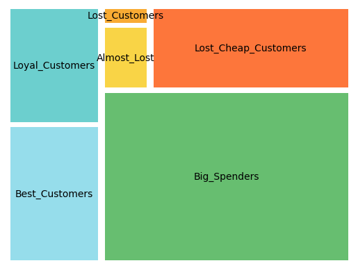

```python
# Treemap
colors = ['#91DCEA', '#64CDCC', '#5FBB68',
          '#F9D23C', '#F9A729', '#FD6F30']

# Treemap
squarify.plot(sizes = Number_customers, label = Segment,
              color = colors, alpha = 0.95,  pad = 0.55)

# Eliminar los ejes:
plt.axis("off")

# plt.show()
```

# FIN

# Exportar a un .csv

```python
rfm_segmentation.to_csv("rfm_segmentation.csv", index = True, sep = ",")
```

```python
rfm_segmentation.head(2864)
```

| CustomerID | Recency | Frequency | Monetary | R_Quartile | F_Quartile | M_Quartile | RFMScore |
| --- | --- | --- | --- | --- | --- | --- | --- |
| 12747 | 109 | 5 | 191.85 | 3 | 4 | 4 | 344 |
| 12748 | 70 | 96 | 1048.83 | 4 | 4 | 4 | 444 |
| 12749 | 130 | 3 | 67.00 | 2 | 3 | 3 | 233 |
| 12820 | 74 | 1 | 15.00 | 4 | 1 | 1 | 411 |
| 12821 | 214 | 1 | 19.92 | 1 | 1 | 2 | 112 |
| ... | ... | ... | ... | ... | ... | ... | ... |
| 18280 | 277 | 1 | 23.70 | 1 | 1 | 2 | 112 |
| 18281 | 180 | 1 | 5.04 | 2 | 1 | 1 | 211 |
| 18282 | 126 | 1 | 12.75 | 2 | 1 | 1 | 211 |
| 18283 | 95 | 7 | 35.95 | 3 | 4 | 3 | 343 |
| 18287 | 201 | 1 | 10.20 | 1 | 1 | 1 | 111 |

2864 rows × 7 columns

# FIN